## **Exploratory Data Analysis - Brazilian Imports/Exports**

official data source for brazilian exports e imports, maintened by the government. The dataset contains all trackings of monthly imports and exports of a range of products (soybeans, soybean meal, soybean oil, corn, wheat and sugar), by brazilian states, by routes (air, sea, ground, etc) e from/to which country;

**Importing:**

```r
# useful library
# install.packages("tidyverse")

# loading library:
library("tidyverse")

# importing data from csv file:
df <- read.table('data/data_comexstat.csv',
                 header = TRUE,
                 sep = ',',
                 dec = '.')
```

**Examine basic dataset information:**

```r
# first rows of dataframe:
head(df)
```

|  | date | product | state | country | type | route | tons | usd |
| --- | --- | --- | --- | --- | --- | --- | --- | --- |
| 1 | 1997-01-01 | corn | ES | United States | Import | Sea | 44.045 | 113029 |
| 2 | 1997-01-01 | corn | GO | Argentina | Import | Ground | 54.000 | 36720 |
| 3 | 1997-01-01 | corn | GO | Bolivia | Export | Ground | 0.200 | 180 |
| 4 | 1997-01-01 | corn | GO | United States | Export | Sea | 3.488 | 5688 |
| 5 | 1997-01-01 | corn | MG | Argentina | Import | Ground | 27.000 | 18630 |
| 6 | 1997-01-01 | corn | MS | Paraguay | Export | Ground | 40.000 | 38700 |

## **Questions:**

##### **Show the evolution of total monthly and total annual exports from Brazil (all states and to everywhere) of ‘soybeans’, ‘soybean oil’ and ‘soybean meal’**

Division in import set and export set:

```r
# import set
df_import <- subset(df, df$type == 'Import')
# removing useless column:
df_import <- df_import[-c(5)]
```

```r
# export set
df_export <- subset(df, df$type == 'Export')
# removing useless column:
df_export <- df_export[-c(5)]
```

slicing by product

```r
# subseting by product
soybeans <- subset(df_export, df_export$product == 'soybeans')
# removing useless column:
soybeans <- soybeans[-c(2, 3 ,4 ,5 ,6)]
# subseting by product:
oil <- subset(df_export, df_export$product == 'soybean_oil')
# removing useless column:
oil <- oil[-c(2, 3 ,4 ,5 ,6)]
# subseting by product
meat <- subset(df_export, df_export$product == 'soybean_meal')
# removing useless column:
meat <- meat[-c(2, 3 ,4 ,5 ,6)]
```

function that creates new columns

```r
YearMonth <- function(df) {
  for (i in 1:nrow(df)) {
    df[i, 'year'] = substr(df[i, 1], 1, 4)
    df[i, 'month'] = substr(df[i, 1], 6, 7)
  }
  return(df)
}

# add new columns to soybeans
soybeans <- YearMonth(soybeans)
soybeans <- soybeans[c("date", "year", "month", "usd")]

# add new columns to oil
oil <- YearMonth(oil)
oil <- oil[c("date", "year", "month", "usd")]

# add new columns to meat
meat <- YearMonth(meat)
meat <- meat[c("date", "year", "month", "usd")]
```

grouping data by year:

```r
soybeans_year <- soybeans %>%
  group_by(year) %>%
    summarize(usd_return = sum(usd))

oil_year <- oil %>%
  group_by(year) %>%
    summarize(usd_return = sum(usd))

meat_year <- meat %>%
  group_by(year) %>%
    summarize(usd_return = sum(usd))
```

grouping data by month:

```r
soybeans_month <- soybeans %>%
  group_by(month) %>%
    summarize(usd_return = sum(usd))

oil_month <- oil %>%
  group_by(month) %>%
    summarize(usd_return = sum(usd))

meat_month <- meat %>%
  group_by(month) %>%
    summarize(usd_return = sum(usd))
```

Visualization:

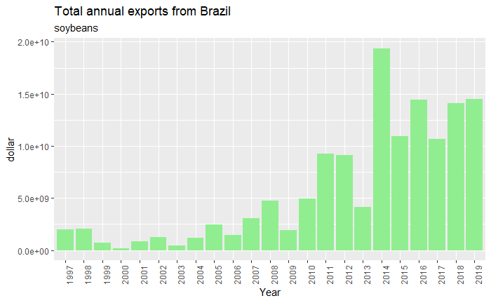

```r
# soybeans
ggplot(soybeans_year, aes(x = year, y = usd_return)) +
  geom_col(fill = "lightgreen") +
  labs(title = "Total annual exports from Brazil",
       subtitle = "soybeans",
       x = "Year",
       y = "dollar")+
  theme(axis.text.x = element_text(angle = 90, hjust = 1))
```

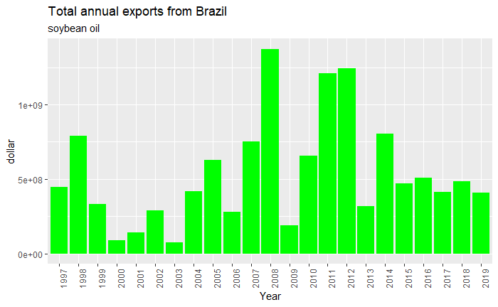

```r
# oil
ggplot(oil_year, aes(x = year, y = usd_return)) +
  geom_col(fill = "green") +
  labs(title = "Total annual exports from Brazil",
       subtitle = "soybean oil",
       x = "Year",
       y = "dollar")+
  theme(axis.text.x = element_text(angle = 90, hjust = 1))
```

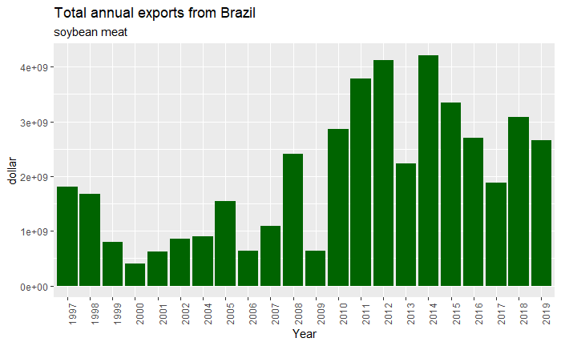

```r
# meat
ggplot(meat_year, aes(x = year, y = usd_return)) +
  geom_col(fill = "darkgreen") +
  labs(title = "Total annual exports from Brazil",
       subtitle = "soybean meat",
       x = "Year",
       y = "dollar")+
  theme(axis.text.x = element_text(angle = 90, hjust = 1))
```

Visualization 2:

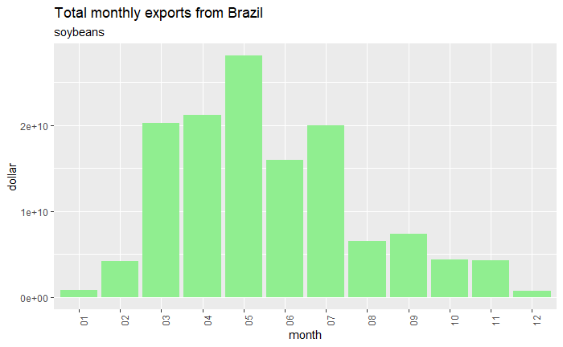

```r
# soybeans
ggplot(soybeans_month, aes(x = month, y = usd_return)) +
  geom_col(fill = "lightgreen") +
  labs(title = "Total monthly exports from Brazil",
       subtitle = "soybeans",
       x = "month",
       y = "dollar")+
  theme(axis.text.x = element_text(angle = 90, hjust = 1))
```

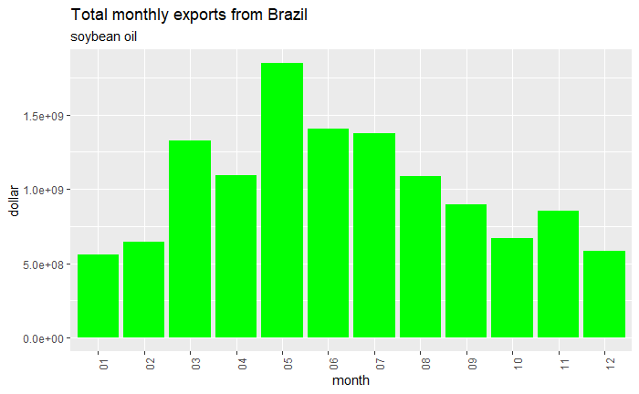

```r
# oil
ggplot(oil_month, aes(x = month, y = usd_return)) +
  geom_col(fill = "green") +
  labs(title = "Total monthly exports from Brazil",
       subtitle = "soybean oil",
       x = "month",
       y = "dollar")+
  theme(axis.text.x = element_text(angle = 90, hjust = 1))
```

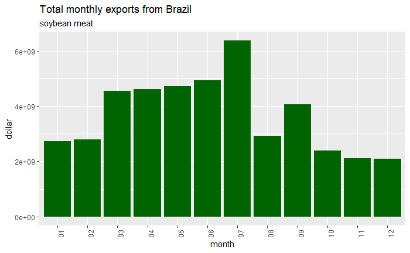

```r
# meat
ggplot(meat_month, aes(x = month, y = usd_return)) +
  geom_col(fill = "darkgreen") +
  labs(title = "Total monthly exports from Brazil",
       subtitle = "soybean meat",
       x = "month",
       y = "dollar")+
  theme(axis.text.x = element_text(angle = 90, hjust = 1))
```

##### **What are the 3 most important products exported by Brazil in the last 5 years?**

```r
# export set
df_export <- subset(df, df$type == 'Export')

# removing useless column:
df_export <- df_export[-c(5)]

# new dataframe of last 5 years:
last5 <- subset(df_export, substr(df$date, 1, 4) == c('2015', '2016', '2017', '2018', '2019'))
# grop by usd return:
product_last5 <- last5 %>%
  group_by(product) %>%
    summarize(usd_return = sum(usd))
# sort by dollar return:
product_last5 <- product_last5 %>% arrange(desc(usd_return))
```

Answer visualization:

[output not shown]

##### **What are the main routes through which Brazil have been exporting ‘corn’ in the last few years? Are there differences in the relative importance of routes depending on the product?**

creating datframe:

```r
# creating a new dataframe with cont exportation in the last 5 years:
corn_last5 <- subset(last5, last5$product == 'corn')
# removing useless column:
corn_last5 <- corn_last5[-c(2)]
```

group by route:

```r
# counting route use:
best_rote <- corn_last5 %>%
  count(route)

# sort by dollar return:
best_rote <- best_rote %>% arrange(desc(n))
```

Answer visualization:

| **Main rote of corn** | **Number of uses from 2015 to 2019** |
| --- | --- |
| **Sea** | 294 |

test with another product:

```r
last5 %>%
  group_by(product, route) %>%
    count(route)
```

| product | route | n |
| --- | --- | --- |
| corn | Air | 28 |
| corn | Ground | 26 |
| corn | Other | 38 |
| corn | River | 17 |
| corn | Sea | 294 |
| soybean_meal | Air | 5 |
| soybean_meal | Ground | 3 |
| soybean_meal | Other | 5 |
| soybean_meal | Sea | 355 |
| soybean_oil | Air | 1 |

[output cut: 17 more lines]

Answer visualization 2:

- the most important route of all products is the sea.

#### **Which countries have been the most important trade partners for Brazil in terms of ‘corn’ and ‘sugar’ in the last 3 years?**

```r
# export set
df_export <- subset(df, df$type == 'Export')

# removing useless column:
df_export <- df_export[-c(5)]

# last 3 years dataset:
last3 <- subset(df_export, substr(df$date, 1, 4) == c('2017', '2018', '2019'))

# filtering by products:
last3_sugar <- subset(last3, last3$product == 'sugar')
last3_corn <- subset(last3, last3$product == 'corn')

# sugar group by usd return:
sugartop <- last3_sugar %>%
  group_by(country) %>%
    summarize(usd_return = sum(usd))

# corn group by usd return:
corntop <- last3_corn %>%
  group_by(country) %>%
    summarize(usd_return = sum(usd))

# sorting valaues:
sugartop <- sugartop %>% arrange(desc(usd_return))
corntop <- corntop %>% arrange(desc(usd_return))
```

Answer visualization:

**the most important trade partners for Brazil in terms of sugar:**|

| **Country** | **Usd return** |
| --- | --- |
| China | 235497558 |
| Algeria | 214996453 |
| Bangladesh | 160869294 |

**the most important trade partners for Brazil in terms of corn:**|

| **Country** | **Usd return** |
| --- | --- |
| Vietnam | 185670299 |
| Spain | 107624116 |
| Iran | 98786485 |

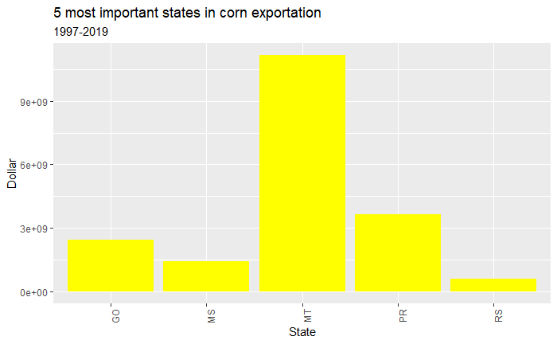

```r
# export set
df_export <- subset(df, df$type == 'Export')

# removing useless column:
df_export <- df_export[-c(5)]

# grouping data by product and country:
important_states <- df_export %>%
  group_by(product, state) %>%
    summarize(usd_return = sum(usd))

# slicing by product to plot:
corn_states <- subset(important_states, important_states$product == 'corn')
meal_states <- subset(important_states, important_states$product == 'soybean_meal')
oil_states <- subset(important_states, important_states$product == 'soybean_oil')
soybeans_states <- subset(important_states, important_states$product == 'soybeans')
wheat_states <- subset(important_states, important_states$product == 'wheat')

# sorting:
corn_states <- corn_states %>% arrange(desc(usd_return))
meal_states <- meal_states %>% arrange(desc(usd_return))
oil_states <- oil_states %>% arrange(desc(usd_return))
soybeans_states <- soybeans_states %>% arrange(desc(usd_return))
wheat_states <- wheat_states %>% arrange(desc(usd_return))

# corn plot:
ggplot(corn_states[1:5,], aes(x = state, y = usd_return)) +
  geom_col(fill = "yellow") +
  labs(title = "5 most important states in corn exportation",
       subtitle = "1997-2019",
       x = "State",
       y = "Dollar")+
  theme(axis.text.x = element_text(angle = 90, hjust = 1))
```

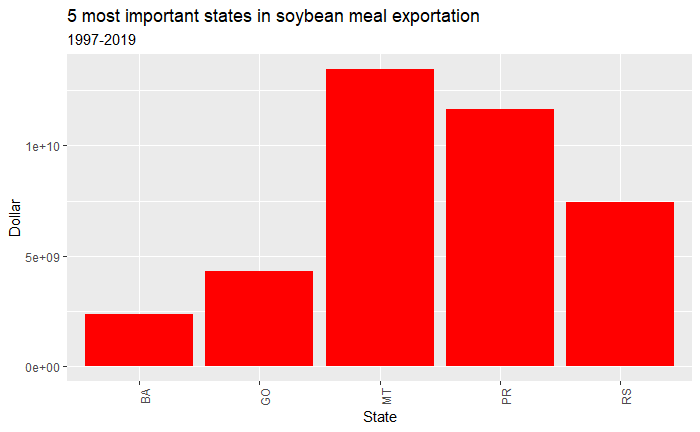

```r
# meal plot:
ggplot(meal_states[1:5,], aes(x = state, y = usd_return)) +
  geom_col(fill = "red") +
  labs(title = "5 most important states in soybean meal exportation",
       subtitle = "1997-2019",
       x = "State",
       y = "Dollar")+
  theme(axis.text.x = element_text(angle = 90, hjust = 1))
```

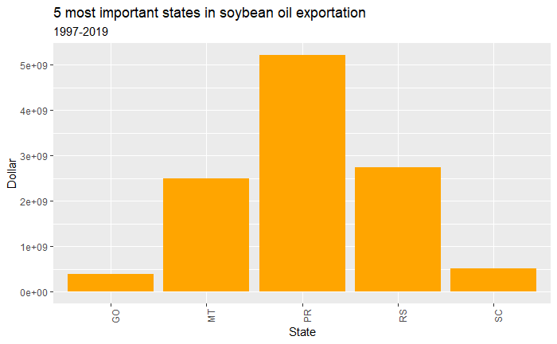

```r
# oil plot:
ggplot(oil_states[1:5,], aes(x = state, y = usd_return)) +
  geom_col(fill = "orange") +
  labs(title = "5 most important states in soybean oil exportation",
       subtitle = "1997-2019",
       x = "State",
       y = "Dollar")+
  theme(axis.text.x = element_text(angle = 90, hjust = 1))
```

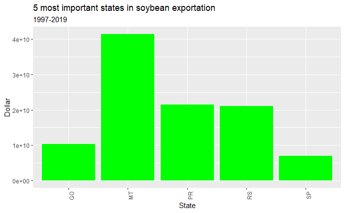

```r
# soybean plot:
ggplot(soybeans_states[1:5,], aes(x = state, y = usd_return)) +
  geom_col(fill = "green") +
  labs(title = "5 most important states in soybean exportation",
       subtitle = "1997-2019",
       x = "State",
       y = "Dollar")+
  theme(axis.text.x = element_text(angle = 90, hjust = 1))
```

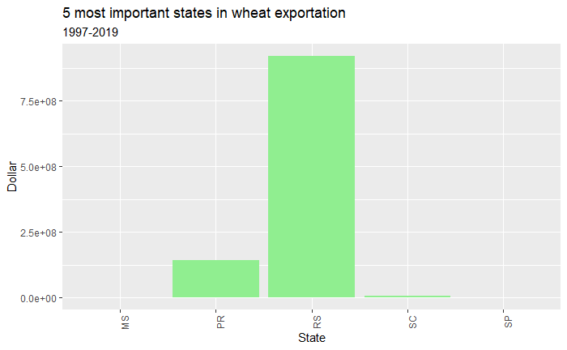

```r
# oil plot:
ggplot(wheat_states[1:5,], aes(x = state, y = usd_return)) +
  geom_col(fill = "lightgreen") +
  labs(title = "5 most important states in wheat exportation",
       subtitle = "1997-2019",
       x = "State",
       y = "Dollar")+
  theme(axis.text.x = element_text(angle = 90, hjust = 1))
```

**observation:**

- some lines in dataframe have errors like: Cote DIvore,Export,Sea,6000,1
- these errors have been ignored until now because they do not interfere in the general analysis.

| year | totalton |
| --- | --- |
| 1997 | 6750960 |
| 1998 | 9947875 |
| 1999 | 5515514 |
| 2000 | 2205806 |
| 2001 | 3314268 |
| 2002 | 4966066 |
| 2003 | 0 |
| 2004 | 4025426 |
| 2005 | 7836472 |
| 2006 | 3304395 |

[output cut: 13 more lines]

in this case I importing coovariates using R studio functions:

| year | price_soybeans | price_corn | price_soybean_meal | gdp_china | gdp_iran | gpd_netherlands | gdp_spain | gdp_thailand | gdp_world | gdp_egypt | gdp_japan | gdp_vietnam | totalTon |
| --- | --- | --- | --- | --- | --- | --- | --- | --- | --- | --- | --- | --- | --- |
| 1997 | 105.76163 | 93.20418 | 124.01265 | 560.7227 | 106.9763 | 152.7382 | 156.7281 | 345.1241 | 173.9366 | 218.6837 | 180.1338 | 299.0952 | 6773862.8 |
| 1998 | 84.16003 | 80.83137 | 77.42172 | 604.4591 | 109.0088 | 159.9169 | 163.7808 | 318.8946 | 178.4590 | 235.0850 | 178.1523 | 316.4427 | 8679492.3 |
| 1999 | 65.92870 | 71.82394 | 67.60175 | 651.0025 | 109.3359 | 167.9127 | 171.4785 | 333.5638 | 184.8835 | 249.4251 | 177.6178 | 331.6320 | 4107199.8 |
| 2000 | 68.99383 | 70.17352 | 82.93492 | 706.3377 | 116.8800 | 174.9651 | 180.2240 | 348.5742 | 193.7579 | 262.8941 | 182.5911 | 354.1829 | 971856.8 |
| 2001 | 63.60515 | 71.27912 | 80.02914 | 765.6701 | 117.8151 | 178.9893 | 187.2527 | 360.4257 | 198.6018 | 272.0954 | 183.3215 | 378.6216 | 4607715.8 |
| 2002 | 71.18536 | 79.01412 | 81.52212 | 835.3460 | 129.9500 | 179.3473 | 192.3085 | 382.4116 | 204.5599 | 280.8024 | 183.5048 | 405.5037 | 6804721.8 |
| 2003 | 87.89047 | 83.71687 | 95.11376 | 918.8806 | 141.9054 | 179.7059 | 198.0778 | 409.9453 | 213.3560 | 289.7881 | 186.2574 | 435.1055 | 1995624.1 |
| 2004 | 104.26547 | 89.00618 | 113.94093 | 1012.6065 | 147.5817 | 183.3001 | 204.2182 | 435.7718 | 224.8772 | 301.6694 | 190.3551 | 469.0437 | 4069810.7 |
| 2005 | 84.10738 | 78.35739 | 91.18021 | 1128.0436 | 155.1083 | 186.9661 | 211.7743 | 454.0742 | 235.8962 | 315.2446 | 193.5911 | 504.2220 | 10284585.6 |
| 2006 | 81.96034 | 96.76378 | 85.95032 | 1271.3051 | 163.3291 | 193.5099 | 220.4570 | 476.7780 | 248.8705 | 336.6812 | 196.3014 | 539.5175 | 6546234.8 |

[output cut: 13 more lines]

spliting data into train and test:

| year | price_soybeans | price_corn | price_soybean_meal | gdp_china | gdp_iran | gpd_netherlands | gdp_spain | gdp_thailand | gdp_world | gdp_egypt | gdp_japan | gdp_vietnam | totalTon |
| --- | --- | --- | --- | --- | --- | --- | --- | --- | --- | --- | --- | --- | --- |
| 1997 | 105.76163 | 93.20418 | 124.01265 | 560.7227 | 106.9763 | 152.7382 | 156.7281 | 345.1241 | 173.9366 | 218.6837 | 180.1338 | 299.0952 | 6750960 |
| 1998 | 84.16003 | 80.83137 | 77.42172 | 604.4591 | 109.0088 | 159.9169 | 163.7808 | 318.8946 | 178.4590 | 235.0850 | 178.1523 | 316.4427 | 9947875 |
| 1999 | 65.92870 | 71.82394 | 67.60175 | 651.0025 | 109.3359 | 167.9127 | 171.4785 | 333.5638 | 184.8835 | 249.4251 | 177.6178 | 331.6320 | 5515514 |
| 2000 | 68.99383 | 70.17352 | 82.93492 | 706.3377 | 116.8800 | 174.9651 | 180.2240 | 348.5742 | 193.7579 | 262.8941 | 182.5911 | 354.1829 | 2205806 |
| 2001 | 63.60515 | 71.27912 | 80.02914 | 765.6701 | 117.8151 | 178.9893 | 187.2527 | 360.4257 | 198.6018 | 272.0954 | 183.3215 | 378.6216 | 3314268 |
| 2002 | 71.18536 | 79.01412 | 81.52212 | 835.3460 | 129.9500 | 179.3473 | 192.3085 | 382.4116 | 204.5599 | 280.8024 | 183.5048 | 405.5037 | 4966066 |
| 2003 | 87.89047 | 83.71687 | 95.11376 | 918.8806 | 141.9054 | 179.7059 | 198.0778 | 409.9453 | 213.3560 | 289.7881 | 186.2574 | 435.1055 | 0 |
| 2004 | 104.26547 | 89.00618 | 113.94093 | 1012.6065 | 147.5817 | 183.3001 | 204.2182 | 435.7718 | 224.8772 | 301.6694 | 190.3551 | 469.0437 | 4025426 |
| 2005 | 84.10738 | 78.35739 | 91.18021 | 1128.0436 | 155.1083 | 186.9661 | 211.7743 | 454.0742 | 235.8962 | 315.2446 | 193.5911 | 504.2220 | 7836472 |
| 2006 | 81.96034 | 96.76378 | 85.95032 | 1271.3051 | 163.3291 | 193.5099 | 220.4570 | 476.7780 | 248.8705 | 336.6812 | 196.3014 | 539.5175 | 3304395 |

[output cut: 6 more lines]

Importing library to use random forest model:

```r
# install.packages("randomForest")
```

```
There were 22 warnings (use warnings() to see them)
```

```r
library(randomForest)

print('I was unable to complete the modeling in the time available, but from here I would use the random forest or some other model to make the predictions')
```

```
[1] "I was unable to complete the modeling in the time available, but from here I would use the random forest or some other model to make the predictions"
```

links interessantes:

https://www.r-bloggers.com/how-to-implement-random-forests-in-r/